# <sub>Beave</sub>R Tutorial

# Visualizations

So we were able to import our external data file into R and check out some basic information about it. But wouldn’t a plot be much more descriptive?

We can do some **basic plotting** with the `plot()` function and its extensions, all of which come with a basic R install.

`hist()` and `plot()` work pretty much the way you’d expect them to. `hist()` requires just one vector of values to produce a histogram, showing the frequency of counts of each value in the vector. Recall that the syntax to call a column of the data is **name of object$name of column**.

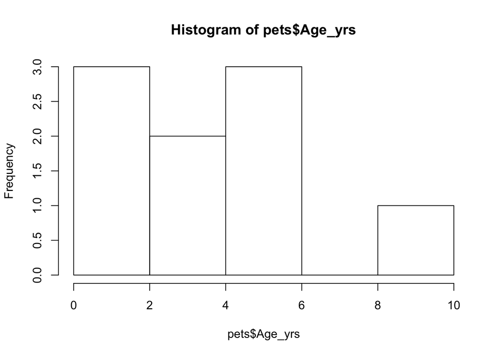

```r
hist(pets$Age_yrs)
```

`plot()` produces an x-y plot when provided with two vectors in the format `plot(x,y)`, again calling columns using object name$column. Remember you can use Tab to complete R’s suggestions for object or column names.

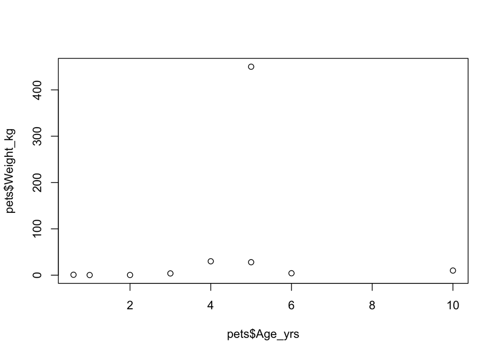

```r
plot(pets$Age_yrs, pets$Weight_kg)
```

Let’s put some axis labels on this plot so it looks more presentable.

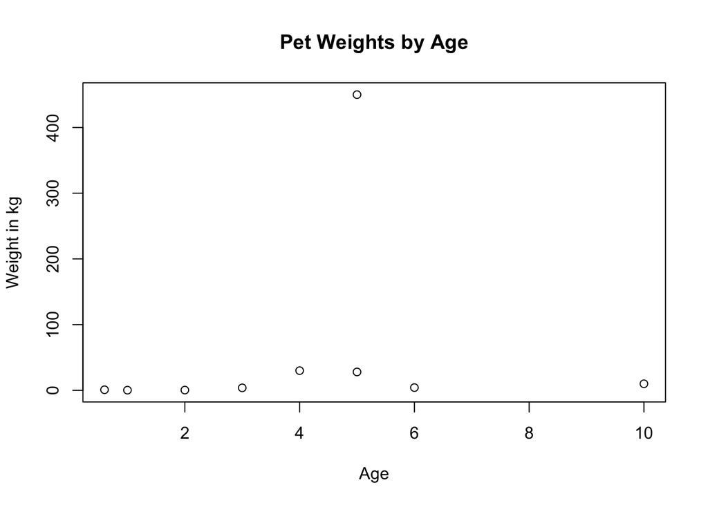

```r
plot(pets$Age_yrs, pets$Weight_kg, xlab = "Age", ylab = "Weight in kg", main = "Pet Weights by Age")
```

First, read in the provided .csv file called pet_stats.csv. Let’s **summarize the dataset** to get a quick glance at the data structure.

```r
pet_stats <- read.csv("pet_stats.csv")
summary(pet_stats)
```

```
##       Year           Dog             Cat
##  Min.   :2000   Min.   :65.00   Min.   :73.00
##  1st Qu.:2004   1st Qu.:73.90   1st Qu.:85.80
##  Median :2008   Median :77.50   Median :88.30
##  Mean   :2009   Mean   :76.47   Mean   :87.39
##  3rd Qu.:2014   3rd Qu.:78.20   3rd Qu.:93.60
##  Max.   :2017   Max.   :89.70   Max.   :95.60
```

Make a plot: you know the drill by now. Let’s add some informative labels, too.

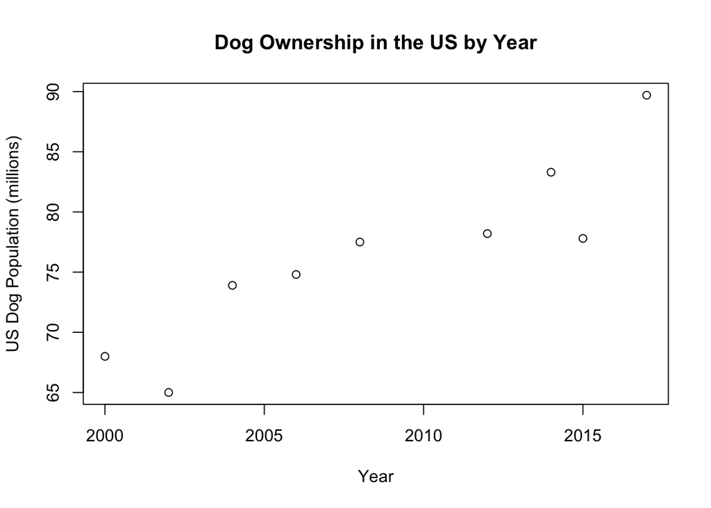

```r
plot(pet_stats$Year,pet_stats$Dog, xlab = "Year", ylab = "US Dog Population (millions)", main = "Dog Ownership in the US by Year")
```

What if we want to compare dog and cat populations across the years to look for trends in pet ownership? One of the unique features of R plots is that we can add information to an existing plot without starting all over. Let’s add more points to our plot using the function `points()`.

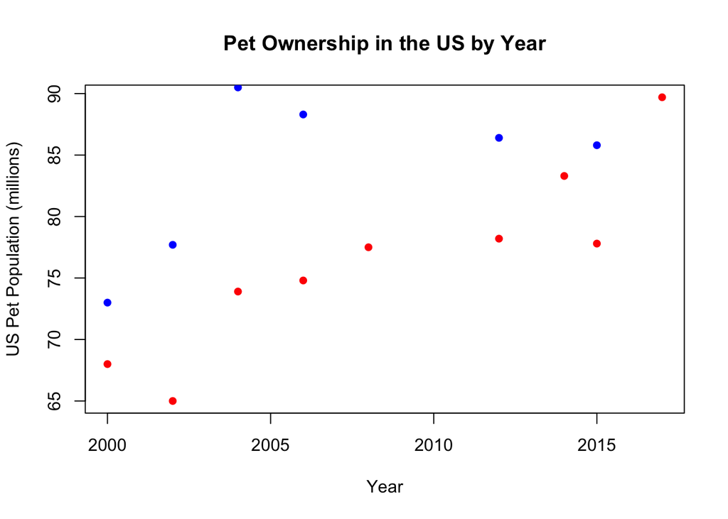

```r
plot(pet_stats$Year,pet_stats$Dog, xlab = "Year", ylab = "US Pet Population (millions)", main = "Pet Ownership in the US by Year",col="red", pch=16) ## Here, we can change the color of the points we are adding so we can distinguish them by data type. Let's make our Dog data red. "pch" means plotting character. I just don't like the way R's default points look.
points(pet_stats$Year,pet_stats$Cat,col="blue", pch=16) #Let's make our Cat data blue.
```

Huh, it looks like some of our Cat data points are getting cut off. This is because we defined the limits of our y axis using the population range for dog ownership. Since R adds elements to a plot in order, we aren’t rebuilding the graph once we add our cat statistics, just adding points to an existing plot.

More people in the US own cats than dogs, so we will have to increase our upper bound for our y axis. We can check the summary we produced earlier to see what the maximum value was for cat population.

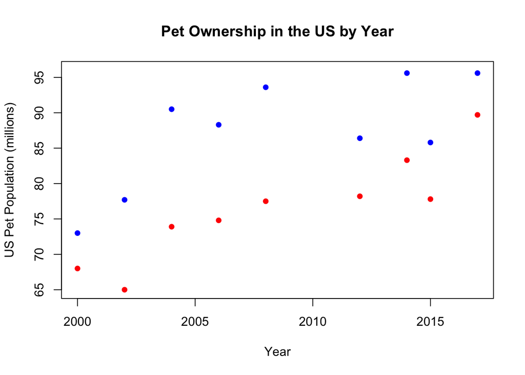

```r
plot(pet_stats$Year,pet_stats$Dog, xlab = "Year", ylab = "US Pet Population (millions)",
     main = "Pet Ownership in the US by Year",
     col="red", pch=16, ylim=c(65,96)) # This sets the y axis range to the minimum value for dogs and the maximum value for cats.
points(pet_stats$Year,pet_stats$Cat,col="blue", pch=16)
```

OK, one last thing. Since we wanted to observe the trends in pet ownership for both cats and dogs, let’s add a **linear regression** line to this plot. This can be done with the function `abline()`, which adds straight lines to a plot. Inside this command, we will nest the function `lm()`, which calculates a linear regression analyzing the relationship between your response variable (y) and your explanatory variable (x).

First, let’s view the linear regression statistics. We’re going to ask R for a summary of our regression statistics using `summary()`. Enter ?summary in the R console to learn more about that function.

Inside the summary function we will nest the `lm()` function to fit a linear model to our data.

```r
summary(lm(pet_stats$Dog ~ pet_stats$Year)) # The ~ symbol means that we are asking lm() to find a relationship between our response variable (dog population in the US) and our explanatory variable (year).
```

```
##
## Call:
## lm(formula = pet_stats$Dog ~ pet_stats$Year)
##
## Residuals:
##    Min     1Q Median     3Q    Max
## -5.606 -1.919  1.029  1.764  4.103
##
## Coefficients:
##                  Estimate Std. Error t value Pr(>|t|)
## (Intercept)    -2124.3040   399.4035  -5.319 0.001101 **
## pet_stats$Year     1.0956     0.1988   5.510 0.000897 ***
## ---
## Signif. codes:  0 '***' 0.001 '**' 0.01 '*' 0.05 '.' 0.1 ' ' 1
##
## Residual standard error: 3.432 on 7 degrees of freedom
## Multiple R-squared:  0.8126, Adjusted R-squared:  0.7859
## F-statistic: 30.36 on 1 and 7 DF,  p-value: 0.0008968
```

Cool! The R-squared value for this regression was 0.785, which suggests that there is a linear relationship between dog population in the US and year, albeit not a very strong one. Let’s see how that regression looks on our plot.

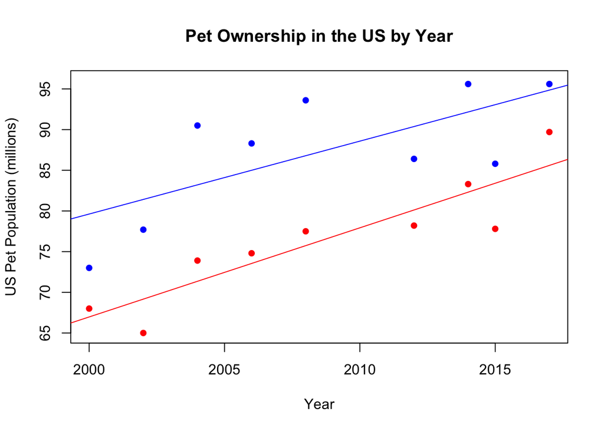

```r
plot(pet_stats$Year,pet_stats$Dog, xlab = "Year", ylab = "US Pet Population (millions)",
     main = "Pet Ownership in the US by Year",
     col="red", pch=16, ylim=c(65,96))
points(pet_stats$Year,pet_stats$Cat,col="blue", pch=16)
abline(lm(pet_stats$Dog~pet_stats$Year), col="red") ## Add a red line of best fit to show trends for our dog data over time.
abline(lm(pet_stats$Cat~pet_stats$Year), col="blue") ## Add a blue line to show trends for our cat data, using the same linear regression function but with cat population as the response variable.
```

And there you have it! You’ve just made a plot from scratch showing trends in dog and cat populations in the US over the last few years. There’s one more thing we should add to this graph, but we’re going to need to learn about packages before we can do that.